# 项目：TMDb电影数据分析

## 目录

- 简介
- 数据整理
- 探索性数据分析
- 结论

## 简介

本数据集中包含 1 万条电影信息，信息来源为“电影数据库”（TMDb，The Movie Database），每行数据录入了有关电影信息的多个数值，包括用户评分和票房等。以“_adj”结尾的最后两列表示了考虑了通货膨胀之后的相关电影的预算和收入（以2010年美元的价值来计算）。

在报告中将探索的问题：

**Q1:**票房高的电影有哪些特点？

**Q2:**有无关键字在评分，投票计数，流行度，收入，预算等特征中的体现有差异吗？

```python
#导入所需数据包
import pandas as pd
import matplotlib.pyplot as plt
%matplotlib inline
import seaborn as sns
import numpy as np
```

## 数据整理

### 常规属性

```python
# 加载数据
df = pd.read_csv('tmdb-movies.csv')
```

```python
df.head(5)
```

|  | id | imdb_id | popularity | budget | revenue | original_title | cast | homepage | director | tagline | ... | overview | runtime | genres | production_companies | release_date | vote_count | vote_average | release_year | budget_adj | revenue_adj |
| --- | --- | --- | --- | --- | --- | --- | --- | --- | --- | --- | --- | --- | --- | --- | --- | --- | --- | --- | --- | --- | --- |
| 0 | 135397 | tt0369610 | 32.985763 | 150000000 | 1513528810 | Jurassic World | Chris Pratt\|Bryce Dallas Howard\|Irrfan Khan\|Vi... | http://www.jurassicworld.com/ | Colin Trevorrow | The park is open. | ... | Twenty-two years after the events of Jurassic ... | 124 | Action\|Adventure\|Science Fiction\|Thriller | Universal Studios\|Amblin Entertainment\|Legenda... | 6/9/15 | 5562 | 6.5 | 2015 | 1.379999e+08 | 1.392446e+09 |
| 1 | 76341 | tt1392190 | 28.419936 | 150000000 | 378436354 | Mad Max: Fury Road | Tom Hardy\|Charlize Theron\|Hugh Keays-Byrne\|Nic... | http://www.madmaxmovie.com/ | George Miller | What a Lovely Day. | ... | An apocalyptic story set in the furthest reach... | 120 | Action\|Adventure\|Science Fiction\|Thriller | Village Roadshow Pictures\|Kennedy Miller Produ... | 5/13/15 | 6185 | 7.1 | 2015 | 1.379999e+08 | 3.481613e+08 |
| 2 | 262500 | tt2908446 | 13.112507 | 110000000 | 295238201 | Insurgent | Shailene Woodley\|Theo James\|Kate Winslet\|Ansel... | http://www.thedivergentseries.movie/#insurgent | Robert Schwentke | One Choice Can Destroy You | ... | Beatrice Prior must confront her inner demons ... | 119 | Adventure\|Science Fiction\|Thriller | Summit Entertainment\|Mandeville Films\|Red Wago... | 3/18/15 | 2480 | 6.3 | 2015 | 1.012000e+08 | 2.716190e+08 |
| 3 | 140607 | tt2488496 | 11.173104 | 200000000 | 2068178225 | Star Wars: The Force Awakens | Harrison Ford\|Mark Hamill\|Carrie Fisher\|Adam D... | http://www.starwars.com/films/star-wars-episod... | J.J. Abrams | Every generation has a story. | ... | Thirty years after defeating the Galactic Empi... | 136 | Action\|Adventure\|Science Fiction\|Fantasy | Lucasfilm\|Truenorth Productions\|Bad Robot | 12/15/15 | 5292 | 7.5 | 2015 | 1.839999e+08 | 1.902723e+09 |
| 4 | 168259 | tt2820852 | 9.335014 | 190000000 | 1506249360 | Furious 7 | Vin Diesel\|Paul Walker\|Jason Statham\|Michelle ... | http://www.furious7.com/ | James Wan | Vengeance Hits Home | ... | Deckard Shaw seeks revenge against Dominic Tor... | 137 | Action\|Crime\|Thriller | Universal Pictures\|Original Film\|Media Rights ... | 4/1/15 | 2947 | 7.3 | 2015 | 1.747999e+08 | 1.385749e+09 |

5 rows × 21 columns

```python
df.info()
```

```
<class 'pandas.core.frame.DataFrame'>
RangeIndex: 10866 entries, 0 to 10865
Data columns (total 21 columns):
id                      10866 non-null int64
imdb_id                 10856 non-null object
popularity              10866 non-null float64
budget                  10866 non-null int64
revenue                 10866 non-null int64
original_title          10866 non-null object
cast                    10790 non-null object
homepage                2936 non-null object
director                10822 non-null object
tagline                 8042 non-null object
keywords                9373 non-null object
overview                10862 non-null object
runtime                 10866 non-null int64
genres                  10843 non-null object
production_companies    9836 non-null object
release_date            10866 non-null object
vote_count              10866 non-null int64
vote_average            10866 non-null float64
release_year            10866 non-null int64
budget_adj              10866 non-null float64
revenue_adj             10866 non-null float64
dtypes: float64(4), int64(6), object(11)
memory usage: 1.7+ MB
```

```python
df.describe()
```

|  | id | popularity | budget | revenue | runtime | vote_count | vote_average | release_year | budget_adj | revenue_adj |
| --- | --- | --- | --- | --- | --- | --- | --- | --- | --- | --- |
| count | 10866.000000 | 10866.000000 | 1.086600e+04 | 1.086600e+04 | 10866.000000 | 10866.000000 | 10866.000000 | 10866.000000 | 1.086600e+04 | 1.086600e+04 |
| mean | 66064.177434 | 0.646441 | 1.462570e+07 | 3.982332e+07 | 102.070863 | 217.389748 | 5.974922 | 2001.322658 | 1.755104e+07 | 5.136436e+07 |
| std | 92130.136561 | 1.000185 | 3.091321e+07 | 1.170035e+08 | 31.381405 | 575.619058 | 0.935142 | 12.812941 | 3.430616e+07 | 1.446325e+08 |
| min | 5.000000 | 0.000065 | 0.000000e+00 | 0.000000e+00 | 0.000000 | 10.000000 | 1.500000 | 1960.000000 | 0.000000e+00 | 0.000000e+00 |
| 25% | 10596.250000 | 0.207583 | 0.000000e+00 | 0.000000e+00 | 90.000000 | 17.000000 | 5.400000 | 1995.000000 | 0.000000e+00 | 0.000000e+00 |
| 50% | 20669.000000 | 0.383856 | 0.000000e+00 | 0.000000e+00 | 99.000000 | 38.000000 | 6.000000 | 2006.000000 | 0.000000e+00 | 0.000000e+00 |
| 75% | 75610.000000 | 0.713817 | 1.500000e+07 | 2.400000e+07 | 111.000000 | 145.750000 | 6.600000 | 2011.000000 | 2.085325e+07 | 3.369710e+07 |
| max | 417859.000000 | 32.985763 | 4.250000e+08 | 2.781506e+09 | 900.000000 | 9767.000000 | 9.200000 | 2015.000000 | 4.250000e+08 | 2.827124e+09 |

### 数据清理

```python
# 检查数据缺失情况
df.isnull().sum()
```

```
id                         0
imdb_id                   10
popularity                 0
budget                     0
revenue                    0
original_title             0
cast                      76
homepage                7930
director                  44
tagline                 2824
keywords                1493
overview                   4
runtime                    0
genres                    23
production_companies    1030
release_date               0
vote_count                 0
vote_average               0
release_year               0
budget_adj                 0
revenue_adj                0
dtype: int64
```

数据集中共9列存在数据缺失，分别是idb_id, cast, homepage, director, tagline, keywords, overview, genres, production_companies，值缺失的原因可能是信没有录入，其中homepage列值缺失最多，可能是因为大多数电影没有建立主页。

```python
#与探索的问题相关的自变量genres的数据缺失查询
df.genres.isnull().sum()
```

```
23
```

```python
#数据冗余
df.duplicated().sum()
```

```
1
```

```python
#删除冗余行
df.drop_duplicates(inplace=True)
```

```python
#确认冗余数据已在dataframe 中删除
df.duplicated().sum()
```

```
0
```

```python
df.shape
```

```
(10865, 21)
```

## 探索性数据分析

### Q1: 票房高的电影有哪些特点？

首先查看收入'revenue_adj'的分布情况。

```python
# 电影票房的概述性统计
df['revenue_adj'].describe()
```

```
count    1.086500e+04
mean     5.136900e+07
std      1.446383e+08
min      0.000000e+00
25%      0.000000e+00
50%      0.000000e+00
75%      3.370173e+07
max      2.827124e+09
Name: revenue_adj, dtype: float64
```

```python
#删除收入为零的电影
df = df.query('revenue != 0')
df.shape
```

```
(4849, 21)
```

```python
df['revenue_adj'].describe()
```

```
count    4.849000e+03
mean     1.151009e+08
std      1.988557e+08
min      2.370705e+00
25%      1.046585e+07
50%      4.395666e+07
75%      1.316482e+08
max      2.827124e+09
Name: revenue_adj, dtype: float64
```

**使用中值将数据集分为高票房组和低票房组：**

```
1.高票房（收入高于或等于中值的电影）
2.低票房（收入低于中值的电影）
```

```python
#获得电影票房的中位数
median = df.revenue_adj.median()
```

```python
#选择收入高于或等于中位数的电影
df_top = df[df['revenue_adj'] >= median]

#选择收入低于中位数的电影
df_low = df[df['revenue_adj'] < median]

# 确保这些查询中的每个样本只出现一次
num_samples = df.shape[0]
num_samples == df_top['revenue'].count() +df_low['revenue'].count() # 应为真
```

```
True
```

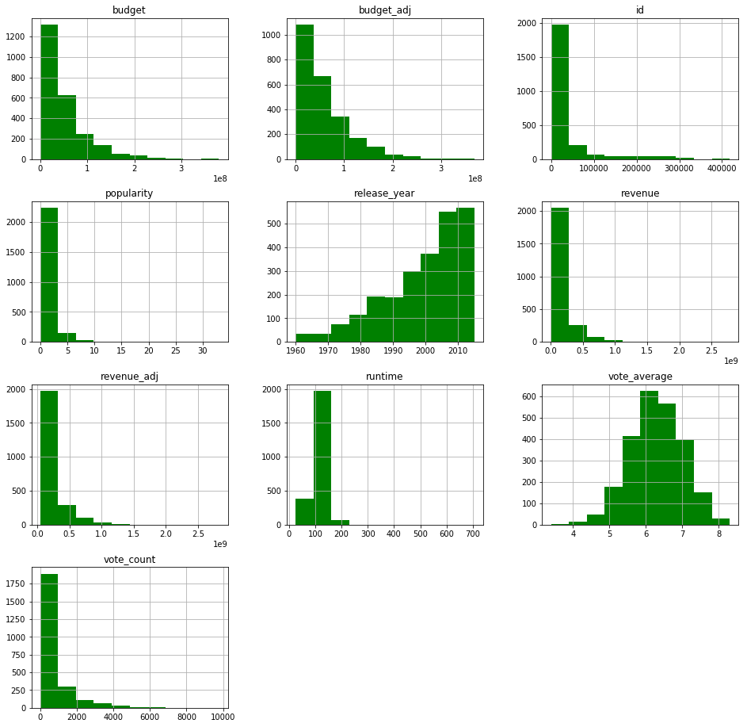

```python
df_top.hist(figsize=(16,16), color='green');
```

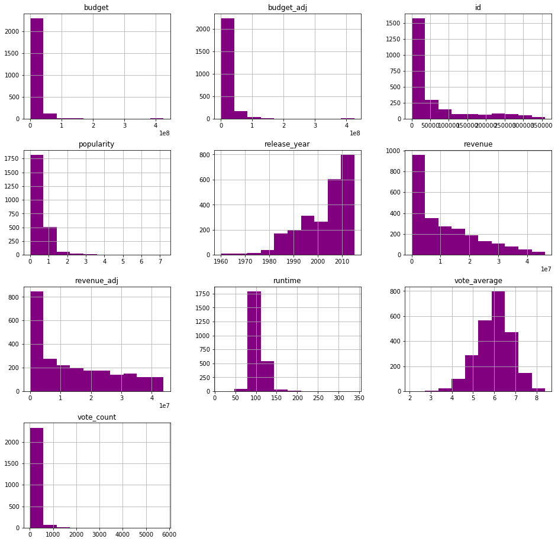

```python
df_low.hist(figsize=(16,16), color='purple');
```

画散点图观察参数两两之间的关系：

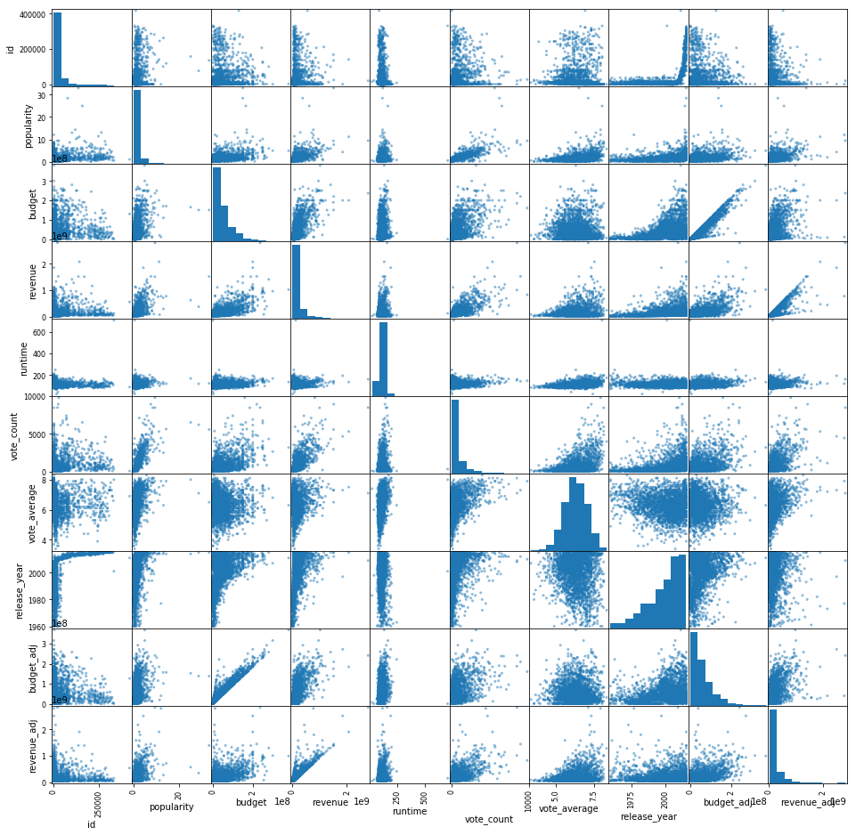

```python
pd.plotting.scatter_matrix(df_top, figsize=(16,16));
```

1. 票房高的电影需要预算更高吗？

```python
high_budget = df_top['budget_adj']
```

```python
low_budget = df_low['budget_adj']
```

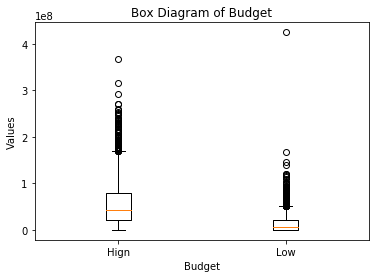

```python
fig = plt.figure()
ax = fig.add_subplot(111)
data =[high_budget, low_budget]

labels = ['Hign','Low']
ax.boxplot(data, labels=labels);
plt.title('Box Diagram of Budget')
plt.xlabel('Budget')
plt.ylabel('Values');
```

**票房高的电影的预算普遍要比票房低的电影预算高，预算特别高的电影基本都属于票房高的这一组。**

1. 票房高的电影有关键字信息的概率更大吗？

```python
high_rve = df_top['keywords'].isnull().sum()/(df_top['keywords'].count())
high_rve
```

```
0.016345347862531435
```

```python
low_rve = df_low['keywords'].isnull().sum()/(df_low['keywords'].count())
low_rve
```

```
0.08797127468581688
```

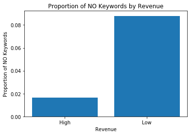

```python
# 创建柱状图
locations = [1, 2]
heights = [high_rve, low_rve]
labels = ['High', 'Low']
plt.bar(locations, heights, tick_label=labels)
plt.title('Proportion of NO Keywords by Revenue')
plt.xlabel('Revenue')
plt.ylabel('Proportion of NO Keywords');
```

**很明显票房高的电影中只有1.63%缺少关键字，票房较低的电影中有8.80%缺少关键字。**

1. 票房高是否与电影流行度相关？

```python
high_pop = df_top['popularity']
high_pop.describe()
```

```
count    2425.000000
mean        1.509101
std         1.725302
min         0.010335
25%         0.636839
50%         1.063015
75%         1.776713
max        32.985763
Name: popularity, dtype: float64
```

```python
low_pop = df_low['popularity']
low_pop.describe()
```

```
count    2424.000000
mean        0.581110
std         0.523763
min         0.001117
25%         0.280511
50%         0.456098
75%         0.721830
max         7.192039
Name: popularity, dtype: float64
```

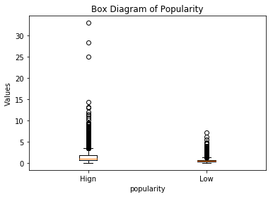

```python
fig = plt.figure()
ax = fig.add_subplot(111)
data =[high_pop, low_pop]

labels = ['Hign','Low']
ax.boxplot(data, labels=labels);
plt.title('Box Diagram of Popularity')
plt.xlabel('popularity')
plt.ylabel('Values');
```

**票房高的电影的流行度比票房较低的电影整体上高一些，流行度大于8的电影的收入都属于票房高的这一组。**

1. 电影收入是否与评分相关

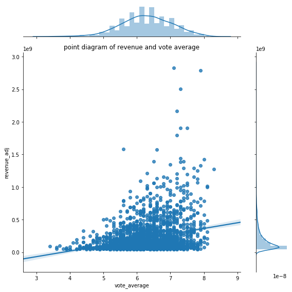

```python
sns.jointplot(data=df_top, y='revenue_adj', x='vote_average', kind="reg", height=8, space=0.5);
plt.title('point diagram of revenue and vote average')
```

电影收入与评分之间相关性较小。

## Q2:有无关键字在评分，投票计数，流行度，收入，预算等特征中的体现有差异吗？

```python
#建立新列 ’has_keywords‘ 用于区分电影是否有关键字
df['has_keywords'] = df['keywords'].notnull()
df.drop('keywords', axis = 1, inplace = True)

print(df.columns[-1:])
df.shape
```

```
Index(['has_keywords'], dtype='object')
```

```
(4849, 21)
```

```python
#删除预算为零的电影
df = df.query('budget != 0')
df.shape
```

```
(3854, 21)
```

```python
#创建一个新的dataframe只包含需要分析的相关列
new_cols = ['popularity','vote_count','vote_average','budget_adj','revenue_adj', 'has_keywords']
df_key = pd.DataFrame()
for i in new_cols:
    df_key[i] = df[i]
df_key.head()
```

|  | popularity | vote_count | vote_average | budget_adj | revenue_adj | has_keywords |
| --- | --- | --- | --- | --- | --- | --- |
| 0 | 32.985763 | 5562 | 6.5 | 1.379999e+08 | 1.392446e+09 | True |
| 1 | 28.419936 | 6185 | 7.1 | 1.379999e+08 | 3.481613e+08 | True |
| 2 | 13.112507 | 2480 | 6.3 | 1.012000e+08 | 2.716190e+08 | True |
| 3 | 11.173104 | 5292 | 7.5 | 1.839999e+08 | 1.902723e+09 | True |
| 4 | 9.335014 | 2947 | 7.3 | 1.747999e+08 | 1.385749e+09 | True |

以是否有关键字信息进行分组，并计算各个特征的平均值。

```python
mean = df_key.groupby('has_keywords').mean()
mean
```

| has_keywords | popularity | vote_count | vote_average | budget_adj | revenue_adj |
| --- | --- | --- | --- | --- | --- |
| False | 0.541109 | 135.818841 | 5.797101 | 2.436778e+07 | 3.952513e+07 |
| True | 1.215709 | 542.274220 | 6.181943 | 4.497798e+07 | 1.406870e+08 |

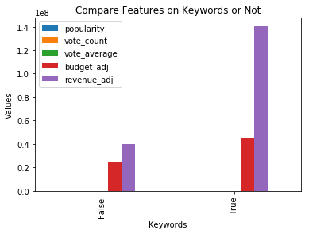

```python
df_key.groupby('has_keywords').mean().plot(kind='bar');
plt.title('Compare Features on Keywords or Not')
plt.xlabel('Keywords')
plt.ylabel('Values');
```

```python
#调整数据的数量级
mean_adj = mean.copy()
mean_adj['budget_adj'] = mean['budget_adj'] / 10000000
mean_adj['revenue_adj'] = mean['revenue_adj'] / 10000000
mean_adj['vote_count'] = mean['vote_count'] /100
mean_adj
```

| has_keywords | popularity | vote_count | vote_average | budget_adj | revenue_adj |
| --- | --- | --- | --- | --- | --- |
| False | 0.541109 | 1.358188 | 5.797101 | 2.436778 | 3.952513 |
| True | 1.215709 | 5.422742 | 6.181943 | 4.497798 | 14.068699 |

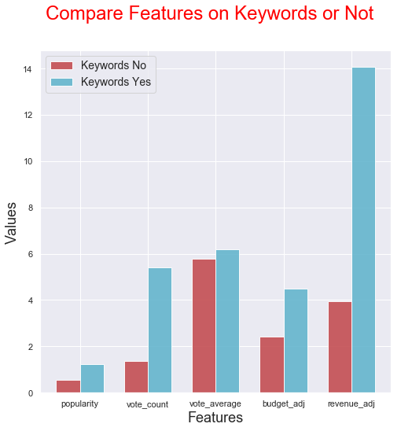

```python
sns.set(context = 'notebook',)
fig = plt.figure(figsize=(8,8))
ax = fig.add_subplot(1,1,1)
ind = np.arange(len(mean_adj.iloc[0]))

w=0.35
ax.bar(ind, mean_adj.iloc[0], color = 'r', alpha = 0.9, width = w, label = "Keywords No")
ax.bar(ind+w, mean_adj.iloc[1], color='c', alpha = 0.9, width = w, label = "Keywords Yes")

ax.legend(loc = 'best', fontsize = 14)
ax.set_xticks(ind+w/2)

mean_label = mean_adj.columns
ax.set_xticklabels(mean_label)

ax.set_ylabel('Values', fontsize=18)
ax.set_xlabel('Features',fontsize=18)
fig.suptitle('Compare Features on Keywords or Not', fontsize=24, color='red');
```

## 结论

**说明：分析得出的结论是暂时的，可能需要改进。**

### Q1:票房高的电影的特点

1. 票房高的电影的预算普遍要比票房低的电影预算高，预算特别高的电影基本都属于票房高的这一组。

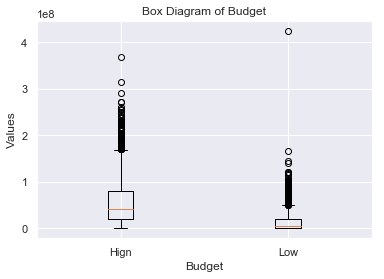

```python
fig = plt.figure()
ax = fig.add_subplot(111)
data =[high_budget, low_budget]

labels = ['Hign','Low']
ax.boxplot(data, labels=labels);
plt.title('Box Diagram of Budget')
plt.xlabel('Budget')
plt.ylabel('Values');
```

1. 票房高的电影有关键字的概率更大。票房高的电影中只有1.63%缺少关键字，而票房较低的电影中有8.80%缺少关键字。

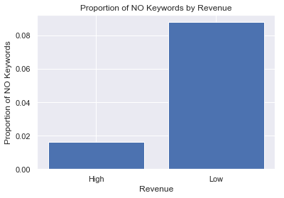

```python
locations = [1, 2]
heights = [high_rve, low_rve]
labels = ['High', 'Low']
plt.bar(locations, heights, tick_label=labels)
plt.title('Proportion of NO Keywords by Revenue')
plt.xlabel('Revenue')
plt.ylabel('Proportion of NO Keywords');
```

1. 票房高的电影的流行度比票房低的电影整体上高一些，流行度大于8的电影的收入都属于票房高的这一组。

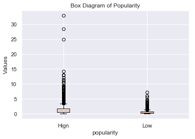

```python
fig = plt.figure()
ax = fig.add_subplot(111)
data =[high_pop, low_pop]

labels = ['Hign','Low']
ax.boxplot(data, labels=labels);
plt.title('Box Diagram of Popularity')
plt.xlabel('popularity')
plt.ylabel('Values');
```

### Q2：有无关键字在评分，投票计数，流行度，收入，预算等特征中的体现

分析结果表明有关键字的电影收入可能会更高，会获得更多的预算，更多的投票计数，和更高的流行度，但是在评分中体现出的差异很小。

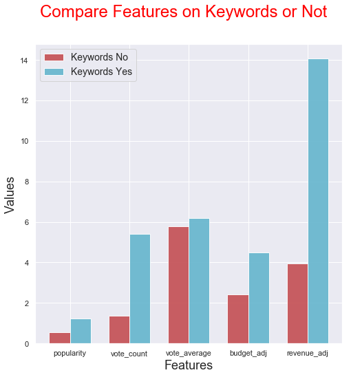

```python
sns.set(context = 'notebook',)
fig = plt.figure(figsize=(8,8))
ax = fig.add_subplot(1,1,1)
ind = np.arange(len(mean_adj.iloc[0]))

w=0.35
ax.bar(ind, mean_adj.iloc[0], color = 'r', alpha = 0.9, width = w, label = "Keywords No")
ax.bar(ind+w, mean_adj.iloc[1], color='c', alpha = 0.9, width = w, label = "Keywords Yes")

ax.legend(loc = 'best', fontsize = 14)
ax.set_xticks(ind+w/2)

mean_label = mean_adj.columns
ax.set_xticklabels(mean_label)

ax.set_ylabel('Values', fontsize=18)
ax.set_xlabel('Features',fontsize=18)
fig.suptitle('Compare Features on Keywords or Not', fontsize=24, color='red');
```

```python
from subprocess import call
call(['python', '-m', 'nbconvert', 'Investigate_a_Dataset.ipynb'])
```